# NYPD-Shooting_Incidents

Seif Elkateb

2025-03-04

## Goal Of the Data Analysis

**This analysis explores the NYPD Shooting Incident Data to identify trends and patterns regarding gun shooting incident and help improve public safety**

### Libraries That will be used

- tidyverse for data analaysis and manipulation/Visualization
- lubridate for tibble mutation , date time modification, adding new columns ,etc

## Importing The CSV File

```r
NYPD_Data= read_csv('./Data/NYPD_Shooting_Incident_Data__Historic_.csv')
```

## Data Tidying

- OCCUR_TIME is NUM , that needs to be modified by using lubridate package
- OCCURDATE Is chr , that needs to be changed to the correct format also by lubridate package (mutate) method
- some columns need to be renamed
- Also some columns are added to the data frame such as Day, Month,Year
- Another Function created to check whether the incident happened on day or night based on the time

### Function to check Day or Night

```r
check_day_night <- function(time) {
  hour <- hour(time)
  case_when(
    hour >= 6 & hour < 18 ~ "Day",
    TRUE ~ "Night"
  )
}
```

```r
# selecting the nypd columns for analysis and renaming some columns

NYPD_Data<-NYPD_Data %>% select(c(VIC_AGE_GROUP,VIC_SEX,VIC_RACE,OCCUR_DATE,OCCUR_TIME,PRECINCT,BORO,
 STATISTICAL_MURDER_FLAG))%>% rename(Victim_Age='VIC_AGE_GROUP',Victim_Race='VIC_RACE',Victim_Sex='VIC_SEX',District='BORO',Murder='STATISTICAL_MURDER_FLAG')


# FIxing the date and time obj and adding new columns for better data analysis

NYPD_Data<-NYPD_Data%>%mutate(FULL_Date=mdy(OCCUR_DATE),TIME=hms(OCCUR_TIME),Day=day(FULL_Date),Month=month(FULL_Date),Year=year(FULL_Date),Day_Night=check_day_night(TIME))
```

### summary of the NYPD Tibble After Data transformation and Tidying

```r
summary(NYPD_Data)
```

```
##   Victim_Age         Victim_Sex        Victim_Race         OCCUR_DATE
##  Length:28562       Length:28562       Length:28562       Length:28562
##  Class :character   Class :character   Class :character   Class :character
##  Mode  :character   Mode  :character   Mode  :character   Mode  :character
##
##
##
##   OCCUR_TIME          PRECINCT       District           Murder
##  Length:28562      Min.   :  1.0   Length:28562       Mode :logical
##  Class1:hms        1st Qu.: 44.0   Class :character   FALSE:23036
##  Class2:difftime   Median : 67.0   Mode  :character   TRUE :5526
##  Mode  :numeric    Mean   : 65.5
##                    3rd Qu.: 81.0
##                    Max.   :123.0
##    FULL_Date               TIME                               Day
##  Min.   :2006-01-01   Min.   :0S                         Min.   : 1.00
##  1st Qu.:2009-09-04   1st Qu.:3H 30M 0S                  1st Qu.: 8.00
##  Median :2013-09-20   Median :15H 15M 0S                 Median :16.00
##  Mean   :2014-06-07   Mean   :12H 44M 16.713115328057S   Mean   :15.92
##  3rd Qu.:2019-09-29   3rd Qu.:20H 45M 0S                 3rd Qu.:24.00
##  Max.   :2023-12-29   Max.   :23H 59M 0S                 Max.   :31.00
##      Month             Year       Day_Night
##  Min.   : 1.000   Min.   :2006   Length:28562
##  1st Qu.: 5.000   1st Qu.:2009   Class :character
##  Median : 7.000   Median :2013   Mode  :character
##  Mean   : 6.805   Mean   :2014
##  3rd Qu.: 9.000   3rd Qu.:2019
##  Max.   :12.000   Max.   :2023
```

### Data Visualization And Analysis

### 1. Bar Plot: Number of Incidents by Borough

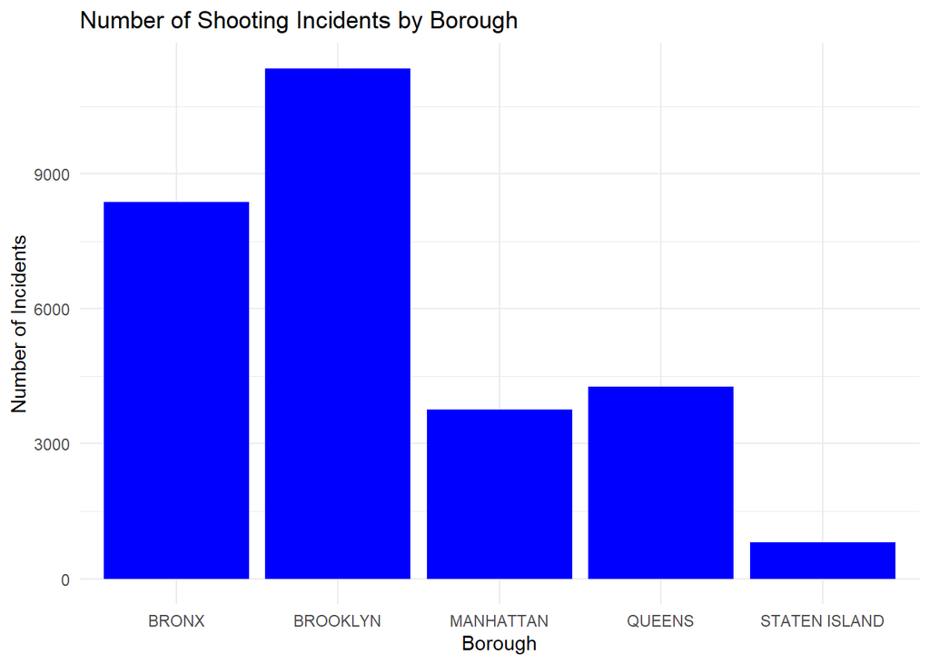

```r
#Bar Plot: Number of Incidents by Borough

ggplot(NYPD_Data, aes(x = District)) +
  geom_bar(fill = "blue") +
  theme_minimal() +
  labs(title = "Number of Shooting Incidents by Borough", x = "Borough", y = "Number of Incidents")
```

**Based on that we can notice that BROOKLYIN has the highst number of shootig incidents !!!**

### Line Plot: Number of Incidents Over Time

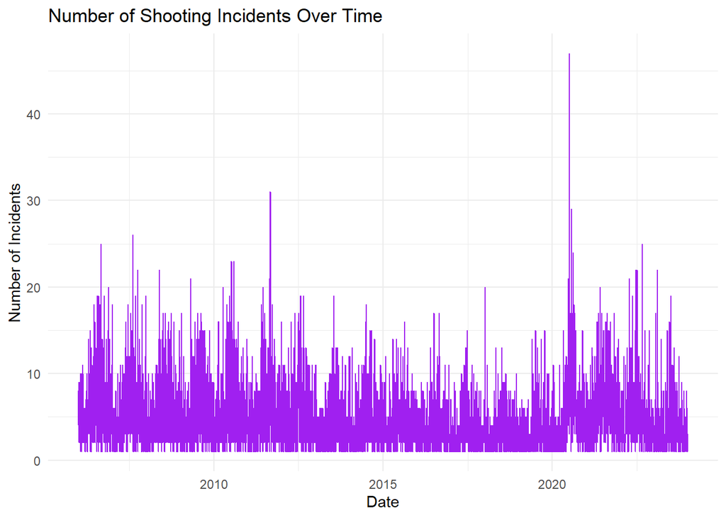

```r
# Summarize the number of incidents by date
incidents_over_time <- NYPD_Data %>%
  group_by(FULL_Date) %>%
  summarize(num_incidents = n()) %>%
  ungroup()

# Line plot for the number of incidents over time
ggplot(incidents_over_time, aes(x = FULL_Date, y = num_incidents)) +
  geom_line(color = "purple") +
  theme_minimal() +
  labs(title = "Number of Shooting Incidents Over Time", x = "Date", y = "Number of Incidents")
```

# Bar plot for the number of incidents by victim’s age group

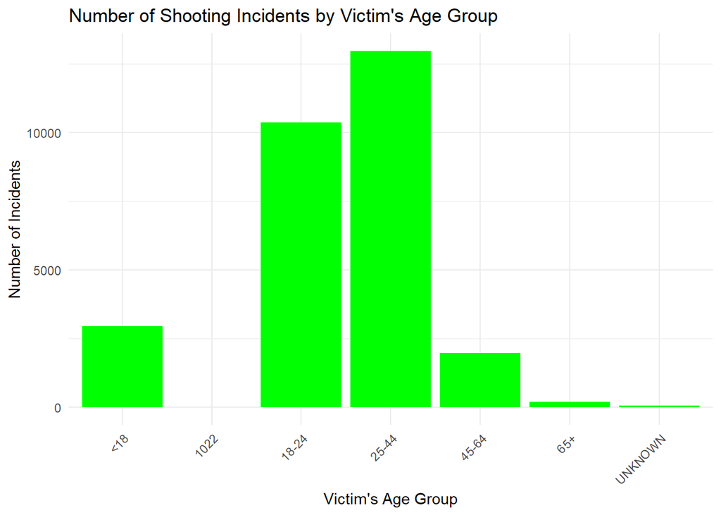

```r
ggplot(NYPD_Data, aes(x = Victim_Age)) +
  geom_bar(fill = "green") +
  theme_minimal() +
  labs(title = "Number of Shooting Incidents by Victim's Age Group", x = "Victim's Age Group", y = "Number of Incidents") +
  theme(axis.text.x = element_text(angle = 45, hjust = 1))
```

**Based on that we can conclude that ages from 25-44 Were the most common targets for shootings incidents followed by 18-24**

### 4. Bar Plot: Number of Incidents by Day/Night

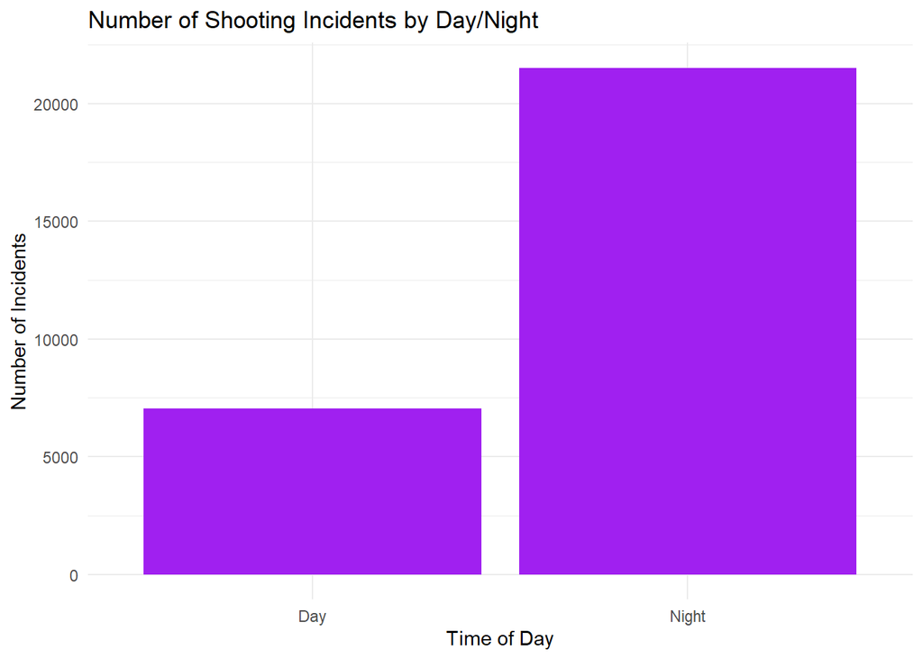

```r
# Bar plot for the number of incidents by day/night
ggplot(NYPD_Data, aes(x = Day_Night)) +
  geom_bar(fill = "purple") +
  theme_minimal() +
  labs(title = "Number of Shooting Incidents by Day/Night", x = "Time of Day", y = "Number of Incidents")
```

**Again Most the shootings incidents happen at night which might not be surprising at all**

### 5. Pie Chart: Proportion of Incidents Resulting in Murder

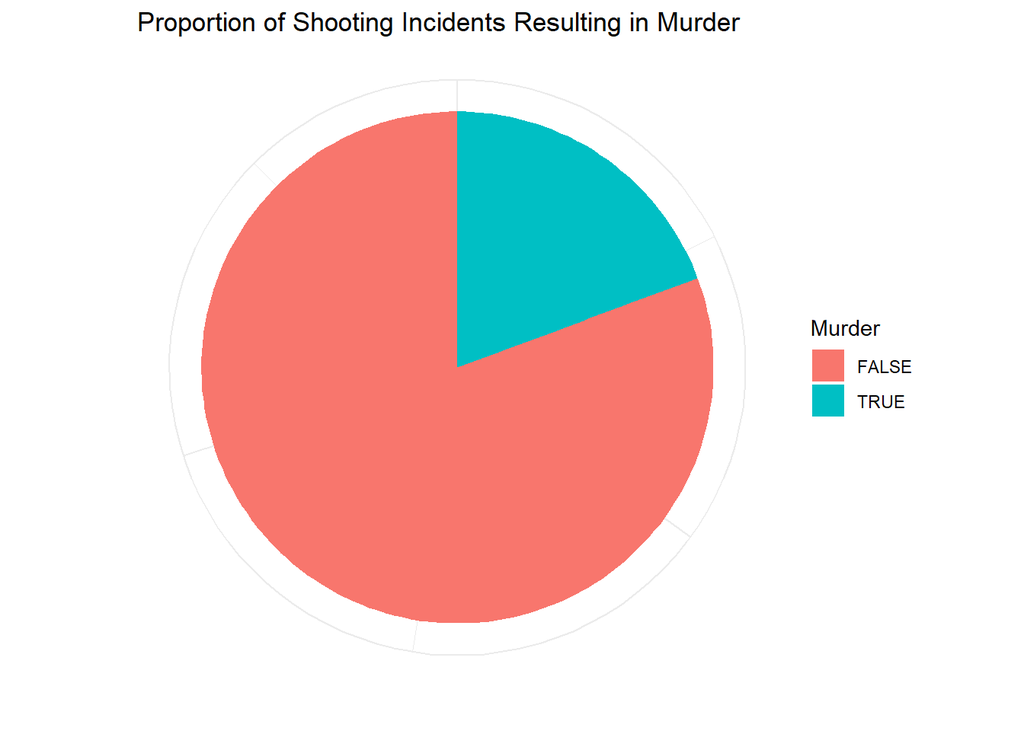

```r
# Summarize the number of incidents resulting in murder
murder_summary <- NYPD_Data %>%
  group_by(Murder) %>%
  summarize(count = n()) %>%
  ungroup()

# Pie chart for the proportion of incidents resulting in murder
ggplot(murder_summary, aes(x = "", y = count, fill = Murder)) +
  geom_bar(stat = "identity", width = 1) +
  coord_polar("y") +
  theme_minimal() +
  labs(title = "Proportion of Shooting Incidents Resulting in Murder", x = "", y = "") +
  theme(axis.text.x = element_blank(), axis.ticks = element_blank())
```

**as we can see about 15-20% of the shootings incidents result in Murder**

### 6. Heatmap: Incidents by Month and Year

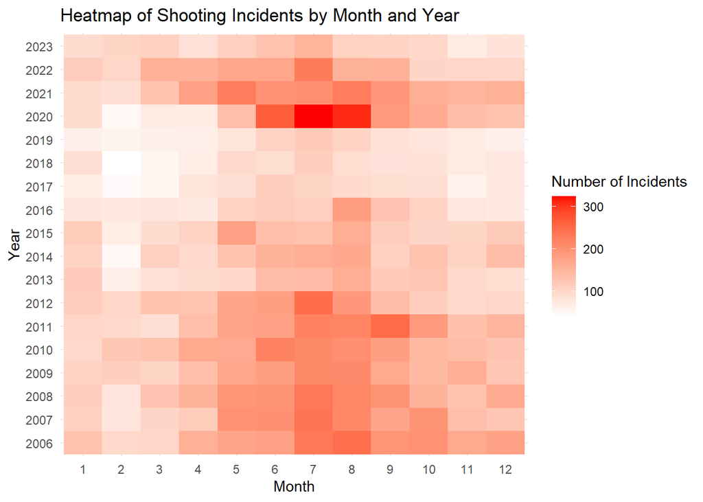

```r
# Summarize the number of incidents by month and year
incidents_by_month_year <- NYPD_Data %>%
  group_by(Year, Month) %>%
  summarize(num_incidents = n()) %>%
  ungroup()

# Create a heatmap
ggplot(incidents_by_month_year, aes(x = factor(Month), y = factor(Year), fill = num_incidents)) +
  geom_tile() +
  scale_fill_gradient(low = "white", high = "red") +
  theme_minimal() +
  labs(title = "Heatmap of Shooting Incidents by Month and Year", x = "Month", y = "Year", fill = "Number of Incidents")
```

**we can see that Summer months from june-September are when most of the shootings incidents occur** **we can also notice that in 2020 months 7/8 had very high number of shooting incidents (that was after lookdown when most people were staying and working from home most of the time )**

### 7. Bar Plot: Number of Incidents by Victim’s Sex

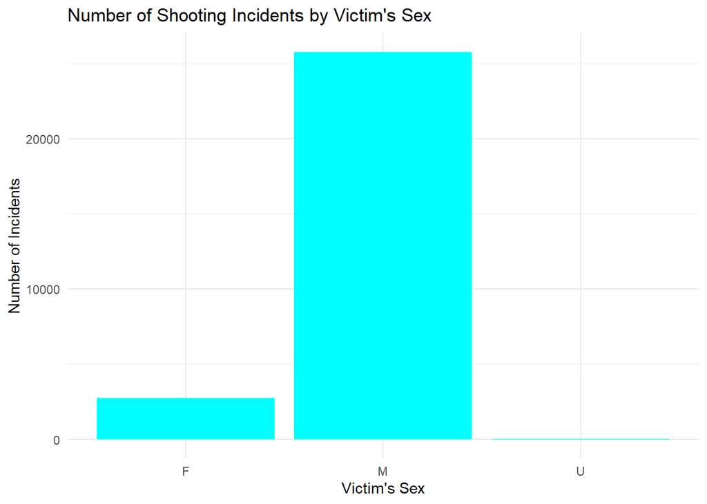

```r
ggplot(NYPD_Data, aes(x = Victim_Sex)) +
  geom_bar(fill = "cyan") +
  theme_minimal() +
  labs(title = "Number of Shooting Incidents by Victim's Sex", x = "Victim's Sex", y = "Number of Incidents")
```

**Most of the shootings victims are Males according to this visualization**

### Data Modeling

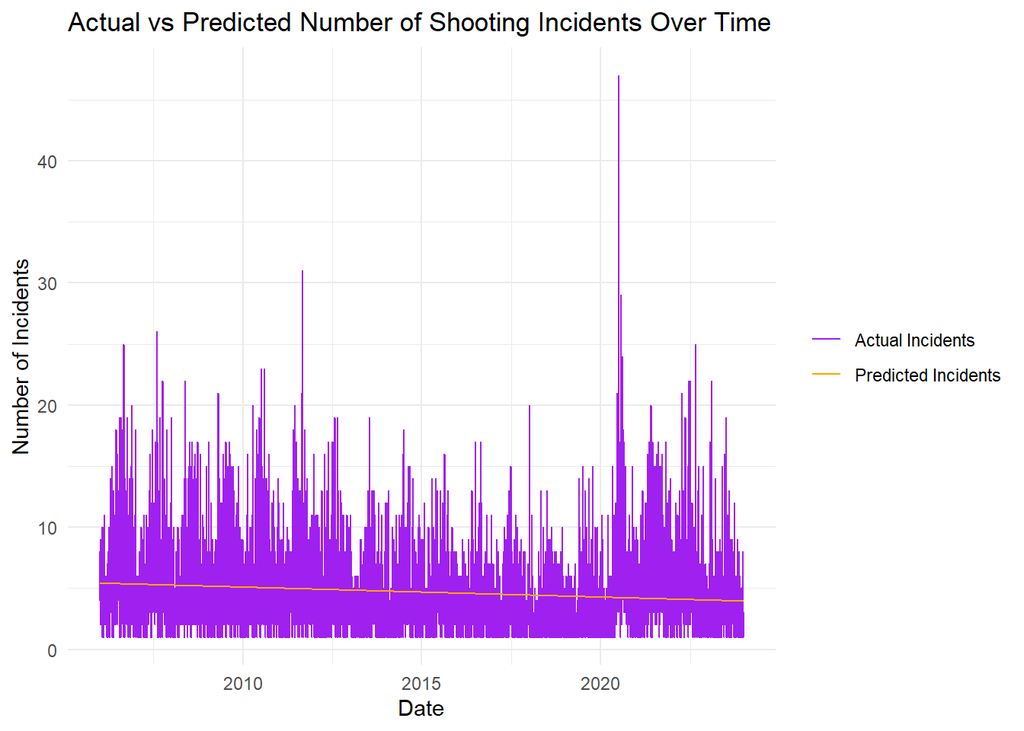

```r
model <- lm(num_incidents ~ as.numeric(FULL_Date), data = incidents_over_time)

# Predict using the model
incidents_over_time <- incidents_over_time %>%
  mutate(predicted_incidents = predict(model, newdata = incidents_over_time))

# Plot actual vs predicted data
ggplot(incidents_over_time, aes(x = FULL_Date)) +
  geom_line(aes(y = num_incidents, color = "Actual Incidents")) +
  geom_line(aes(y = predicted_incidents, color = "Predicted Incidents")) +
  theme_minimal() +
  labs(title = "Actual vs Predicted Number of Shooting Incidents Over Time", x = "Date", y = "Number of Incidents") +
  scale_color_manual(values = c("Actual Incidents" = "purple", "Predicted Incidents" = "orange")) +
  theme(legend.title = element_blank())
```

**as we can see the model actually predicts alot of values close to the range of incidents , however there are alot of outliers and specific years where shooting incidents increased significantly**

### Bias Identification

**Im not from Us and in my country shooting incidents are less common so im initially i might not have been full aware of all the possible factors that could affect the likelihood of shooting incidents.And to mitigate that i tried to add alot of variables into my analysis and make to make it more efficient such as day , month , year and also focus on the victims age groups and their sex and try to utilize every variable available in my data frame to get better and more meaningful results**

### Conclusion

**Analyzing the data is important because it help us improve government policies and identify how might be at risk and then minimize that risk so the data analysis of the dataset is cruicial for a better future and less incidents but this process is a never ending process and things keep changing , people keep changing so the data should always be analyzed , wrangled , visualized and after all of that strong and accurate models should be avilable to help us detect hotspots and trends and minimize risk for the society**